# Assignment 3: Sentiment Classification Reflection

## Open question

1. Both MLP and LSTM model show overfitting. The loss decrease, and accuracy and f1 learning increase. Acc and F1 metrics plateau or fluctuate in early epochs and have a large gap between training and validation performance. Increasing dropout layers might can improve generalization to reduce the effect of overfitting. Using class weight can forced the model to think about the minority positive and negative classes that can increase the accuracy and F1.
2. From the confusion matrixs of MLP and LSTM, MLP have more accurate than LSTM. In general, MLP is better. However, F1 and Sentiment Classification focus on the positive and negative class. In this case, LSTM is better model. Class 2 was most frequently misclassified. In the MLP matrix: 69 positives were misclassified as neutral with total 204, and 15 negatives were misclassified as neutral with total 91. In the LSTM matrix: 58 positives were misclassified as neutral, and 15 negatives were misclassified as neutral. There is around 29% of positives were misclassified as neutral, which is larger than others.

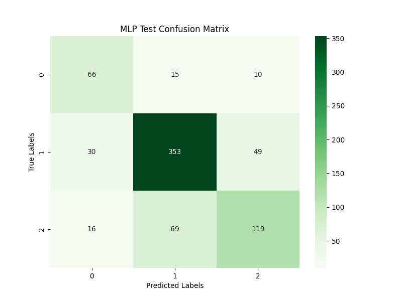

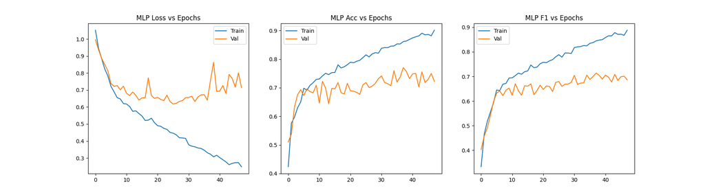

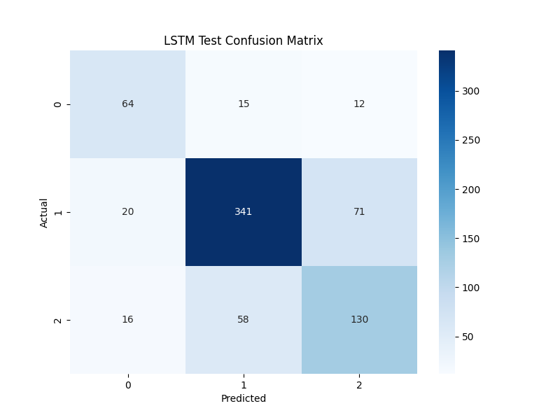

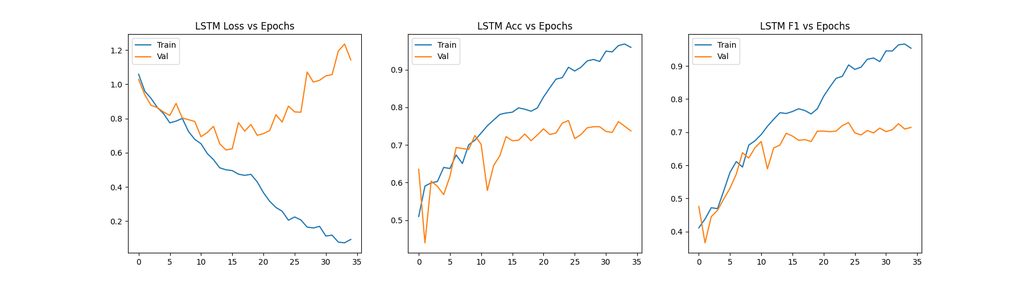

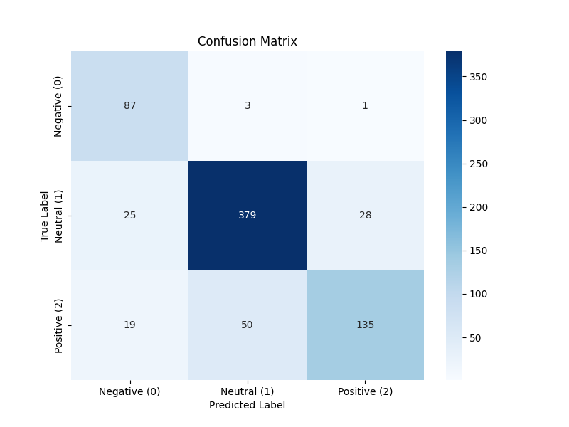

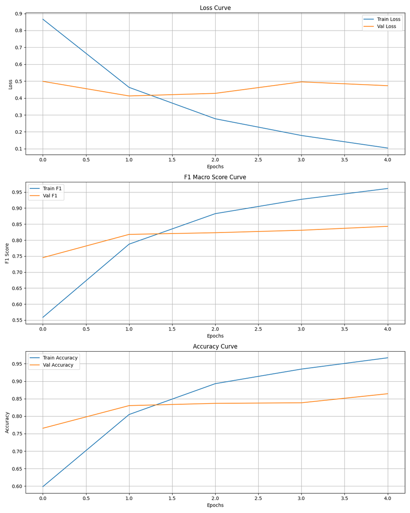

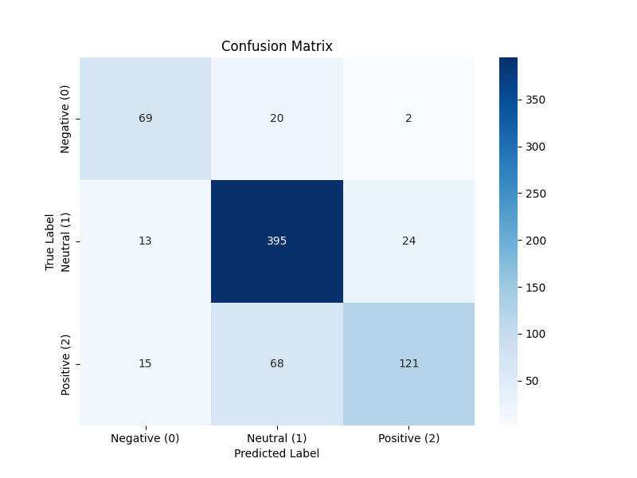

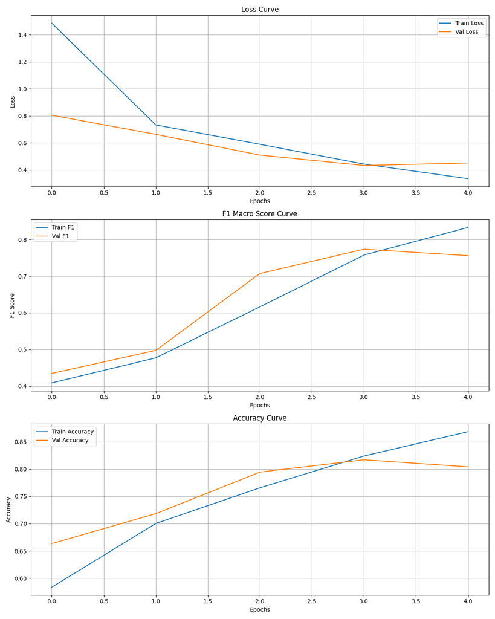

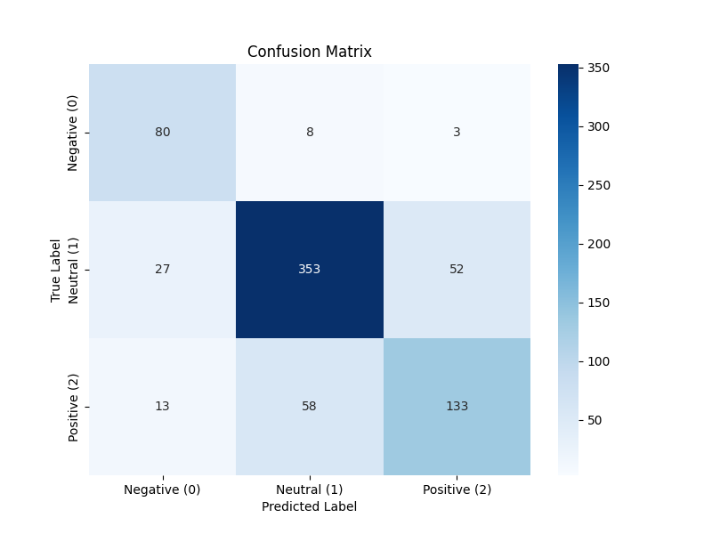

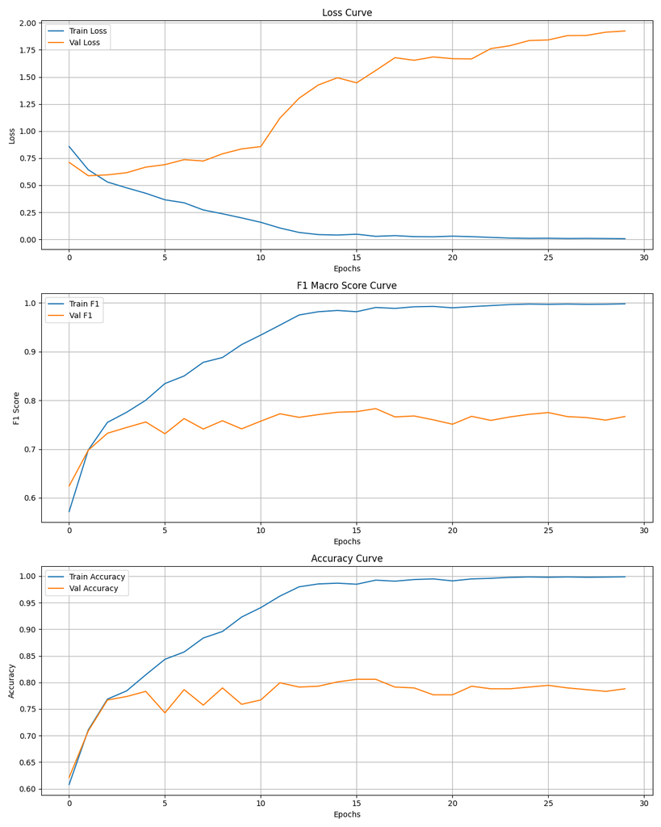

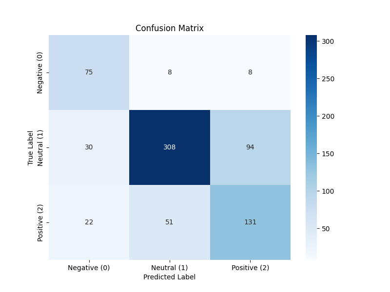

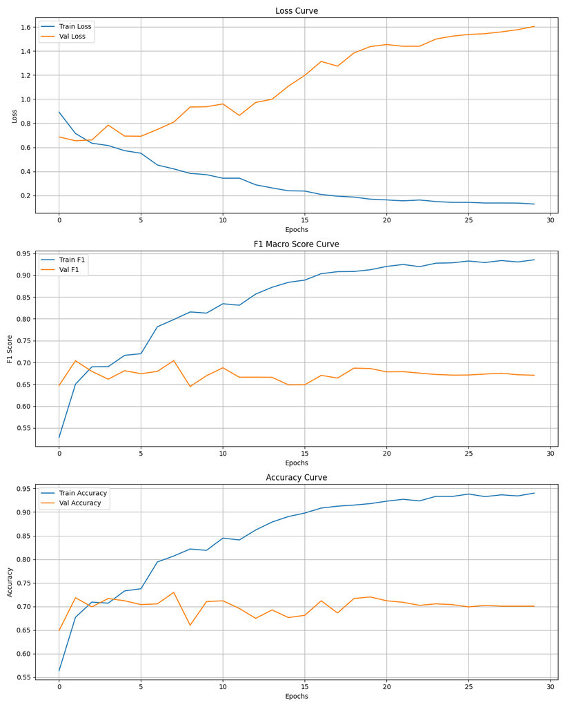

## AI Use Disclosure (Required)

If you used any AI-enabled tools (e.g., ChatGPT, GitHub Copilot, Claude, or other LLM assistants) while working on this assignment, you must disclose that use here. The goal is transparency-not punishment.

In your disclosure, briefly include: - **Tool(s) used:** (name + version if known) - **How you used them:** (e.g., concept explanation, debugging, drafting code, rewriting text) - **What you verified yourself:** (e.g., reran the notebook, checked outputs/plots, checked shapes, read documentation) - **What you did *not* use AI for (if applicable):** (optional)

You are responsible for the correctness of your submission, even if AI suggested code or explanations.

- **Tool(s) used:** Gemini 3
- **How you used them:** for the LSTM model, there are some final output do not achieve 0.7. I ask gemini, should I add more epoch, gemini give me some addvice that we can let epoch = 50 and give a early stop, which can help the output to get a better result. I also notice there is pytorch save in the handout, so I combined both way to get a better performance.
- **What you verified yourself:** I compared the differences between the 6 models and calculated the accuracy of MLP and LSTM to compare MLP and LSTM.